# IODS course project

**Exercise 3, Marja Holm, 10.2.2017**

**2. Read the joined student alcohol consumption data into R either from your local folder or from the url. Print out the names of the variables in the data and describe the data set briefly, assuming the reader has no previous knowledge of it.**

```r
alc <- read.table("http://s3.amazonaws.com/assets.datacamp.com/production/course_2218/datasets/alc.txt", sep = "," , header=TRUE)

#the structure of the data
str(alc)
```

```
## 'data.frame':    382 obs. of  35 variables:
##  $ school    : Factor w/ 2 levels "GP","MS": 1 1 1 1 1 1 1 1 1 1 ...
##  $ sex       : Factor w/ 2 levels "F","M": 1 1 1 1 1 2 2 1 2 2 ...
##  $ age       : int  18 17 15 15 16 16 16 17 15 15 ...
##  $ address   : Factor w/ 2 levels "R","U": 2 2 2 2 2 2 2 2 2 2 ...
##  $ famsize   : Factor w/ 2 levels "GT3","LE3": 1 1 2 1 1 2 2 1 2 1 ...
##  $ Pstatus   : Factor w/ 2 levels "A","T": 1 2 2 2 2 2 2 1 1 2 ...
##  $ Medu      : int  4 1 1 4 3 4 2 4 3 3 ...
##  $ Fedu      : int  4 1 1 2 3 3 2 4 2 4 ...
##  $ Mjob      : Factor w/ 5 levels "at_home","health",..: 1 1 1 2 3 4 3 3 4 3 ...
##  $ Fjob      : Factor w/ 5 levels "at_home","health",..: 5 3 3 4 3 3 3 5 3 3 ...
##  $ reason    : Factor w/ 4 levels "course","home",..: 1 1 3 2 2 4 2 2 2 2 ...
##  $ nursery   : Factor w/ 2 levels "no","yes": 2 1 2 2 2 2 2 2 2 2 ...
##  $ internet  : Factor w/ 2 levels "no","yes": 1 2 2 2 1 2 2 1 2 2 ...
##  $ guardian  : Factor w/ 3 levels "father","mother",..: 2 1 2 2 1 2 2 2 2 2 ...
```

[output cut: 21 more lines]

```r
#the dimensions of the data
dim(alc)
```

```
## [1] 382  35
```

**Describe the data set briefly, assuming the reader has no previous knowledge of it.**

This data consists of 382 observations and 35 variables.

*Factor variables:*

1. school: student’s school (binary: ‘GP’ - Gabriel Pereira or ‘MS’ - Mousinho da Silveira)
2. sex: student’s sex (binary: ‘F’ - female or ‘M’ - male)
3. adress: student’s home address type (binary: ‘U’ - urban or ‘R’ - rural)
4. famsize: family size (binary: ‘LE3’ - less or equal to 3 or ‘GT3’ - greater than 3)
5. Pstatus: parent’s cohabitation status (binary: ‘T’ - living together or ‘A’ - apart)
6. Mjob: mother’s job (nominal, ‘teacher’, ‘health’ care related, civil ‘services’, ‘at_home’ or ‘other’)
7. Fjob: father’s job (nominal, ‘teacher’, ‘health’ care related, civil ‘services’, ‘at_home’ or ‘other’)
8. reason: reason to choose this school (nominal: close to ‘home’, school ‘reputation’, ‘course’ preference or ‘other’)
9. nursery:attended nursery school (binary: yes or no)
10. internet:Internet access at home (binary: yes or no)
11. guardian: student’s guardian (nominal: ‘mother’, ‘father’ or ‘other’)
12. schoolsup:extra educational support (binary: yes or no)
13. famsup: family educational support (binary: yes or no)
14. paid:extra paid classes within the course subject (Math or Portuguese) (binary: yes or no)
15. activities:extra-curricular activities (binary: yes or no)
16. higher:wants to take higher education (binary: yes or no)
17. romantic:with a romantic relationship (binary: yes or no)

*Integer variables:*

18. age: student’s age (numeric: from 15 to 22)
19. Medu: mother’s education (numeric: 0-none, 1-primary, 3-secondary or 4-higher)
20. Fedu: father’s education (numeric: 0-none, 1-primary, 3-secondary or 4-higher)
21. traveltime: home to school travel time (numeric: 1 - <15 min., 2 - 15 to 30 min., 3 - 30 min. to 1 hour, or 4 - >1 hour)
22. studytime: weekly study time (numeric: 1 - <2 hours, 2 - 2 to 5 hours, 3 - 5 to 10 hours, or 4 - >10 hours)
23. failures: number of past class failures (numeric: n if 1<=n<3, else 4)
24. famrel: quality of family relationships (numeric: from 1 - very bad to 5 - excellent)
25. freetime: free time after school (numeric: from 1 - very low to 5 - very high)
26. goout: going out with friends (numeric: from 1 - very low to 5 - very high)
27. Dalc: workday alcohol consumption (numeric: from 1 - very low to 5 - very high)
28. Walc: weekend alcohol consumption (numeric: from 1 - very low to 5 - very high)
29. health: current health status (numeric: from 1 - very bad to 5 - very good)
30. absences: number of school absences (numeric: from 0 to 93)
31. G1: first period grade (numeric: from 0 to 20)
32. G2: second period grade (numeric: from 0 to 20)
33. G3: final grade (numeric: from 0 to 20, output target)

*Numeric:*

34. alc_use: average of weekday and weekend alcohol use

*Logical:*

35. high_use: TRUE if ‘alc_use’ is higher than 2 and FALSE otherwise

**3. The purpose of your analysis is to study the relationships between high/low alcohol consumption and some of the other variables in the data. To do this, choose 4 interesting variables in the data and for each of them, present your personal hypothesis about their relationships with alcohol consumption.**

We selected variables that might have relationships with alcohol consumption.

H1. Going out with friends (goout) might have a positive association with alcohol consumption (alc_use).

H2. Weekly study time (studytime) might have a negative association with alcohol consumption (alc_use).

H4. Number of past class failures (failures) might have a positive association with alcohol consumption (alc_use).

**4. Numerically and graphically explore the distributions of your chosen variables and their relationships with alcohol consumption (use for example cross-tabulations, bar plots and box plots). Comment on your findings and compare the results of your exploration to your previously stated hypotheses.**

First, the data (named: dta) including only study variables (goout, studytime, age, failures, alc_use, high_use) were created.

```r
#Access the dplyr library
library(dplyr)
#Choosing what columns are kept for analysis dataset
keep_columns<-c("goout","studytime","age", "failures", "alc_use", "high_use")
```

```r
#Access the dplyr library
library(dplyr)
#Creating analysis dataset that includes these variables
dta <- select(alc, one_of(keep_columns))
str(dta)
```

```
## 'data.frame':    382 obs. of  6 variables:
##  $ goout    : int  4 3 2 2 2 2 4 4 2 1 ...
##  $ studytime: int  2 2 2 3 2 2 2 2 2 2 ...
##  $ age      : int  18 17 15 15 16 16 16 17 15 15 ...
##  $ failures : int  0 0 3 0 0 0 0 0 0 0 ...
##  $ alc_use  : num  1 1 2.5 1 1.5 1.5 1 1 1 1 ...
##  $ high_use : logi  FALSE FALSE TRUE FALSE FALSE FALSE ...
```

```r
#Saving the R.file into scv format. Before this the working directory has been changed to IODS-project and under Data folder.
write.table(dta, file="dta.csv")
 dta<-read.table("dta.csv")
```

**4.1. Numerically and graphically explore the distributions of your chosen variables and their relationships with alcohol consumption**

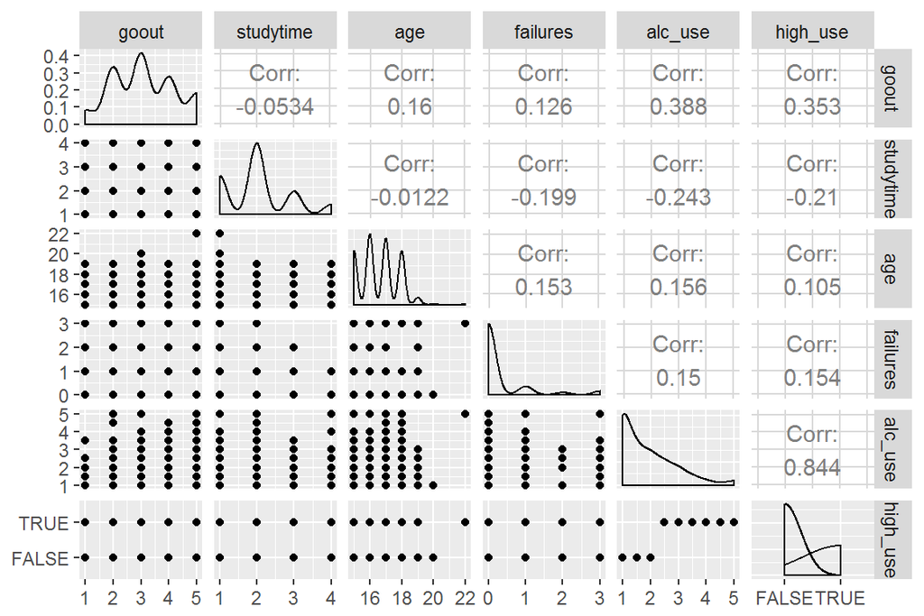

```r
# access the GGally and ggplot2 libraries
library(GGally)
library(ggplot2)

# a more advanced plot matrix with ggpairs()
p <- ggpairs(dta,  mapping = aes(),lower = list(combo = wrap("facethist", bins = 20)))

# draw the plot
p
```

*Figure 1. Correlations and distributions*

```r
ta0<-xtabs(~alc_use+goout, data=dta)
ta0
```

```
##        goout
## alc_use  1  2  3  4  5
##     1   16 49 45 25  9
##     1.5  3 22 29  8  6
##     2    2 13 26 10  7
##     2.5  2  7 13 16  4
##     3    0  4  3 14 11
##     3.5  1  2  4  3  7
##     4    0  0  1  5  3
##     4.5  0  1  0  1  1
##     5    0  1  2  0  6
```

*Table1. Cross-tabulations: Relationships between alcohol use (alc_use) and going out with friends (goout)*

```r
ta1<-xtabs(~alc_use+studytime, data=dta)
ta1
```

```
##        studytime
## alc_use  1  2  3  4
##     1   22 74 31 17
##     1.5 21 33 10  4
##     2   17 26 13  2
##     2.5 11 25  5  1
##     3   12 18  1  1
##     3.5 11  4  2  0
##     4    4  4  0  1
##     4.5  0  3  0  0
##     5    5  3  0  1
```

*Table 2. Cross-tabulations: relationships between alcohol use (alc_use) and weekly study time (studytime)*

```r
ta2<-xtabs(~alc_use+age, data=dta)
ta2
```

```
##        age
## alc_use 15 16 17 18 19 20 22
##     1   46 41 26 27  3  1  0
##     1.5  9 24 20 12  3  0  0
##     2    8 14 19 16  1  0  0
##     2.5  8  9 16  8  1  0  0
##     3    4  9  8  8  3  0  0
##     3.5  3  3  5  6  0  0  0
##     4    2  4  2  1  0  0  0
##     4.5  0  0  2  1  0  0  0
##     5    1  3  2  2  0  0  1
```

*Table 3. Cross-tabulations: relationships between alcohol use (alc_use) and age*

```r
ta3<-xtabs(~alc_use+failures, data=dta)
ta3
```

```
##        failures
## alc_use   0   1   2   3
##     1   127  10   1   6
##     1.5  60   6   0   2
##     2    47   6   4   1
##     2.5  36   3   2   1
##     3    20   4   4   4
##     3.5  10   5   0   2
##     4     6   3   0   0
##     4.5   3   0   0   0
##     5     7   1   0   1
```

*Table 4. Cross-tabulations: relationships between alcohol use and number of past class failures (failures)*

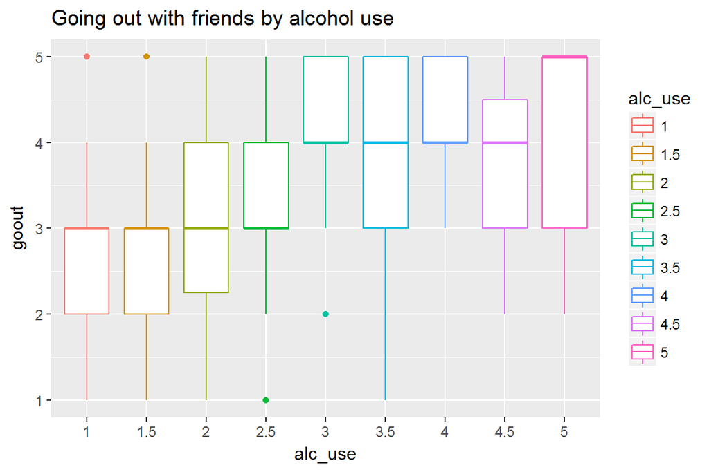

```r
library(ggplot2)

alc$alc_use<-as.factor(alc$alc_use)
# initialise a plot of high_use and absences
g2 <- ggplot(alc, aes(x = alc_use, y = goout))

# define the plot as a boxplot and draw it
g2 + geom_boxplot() + ylab("goout")+aes(col=alc_use)+ggtitle("Going out with friends by alcohol use")
```

*Figure 2. Box plots I*

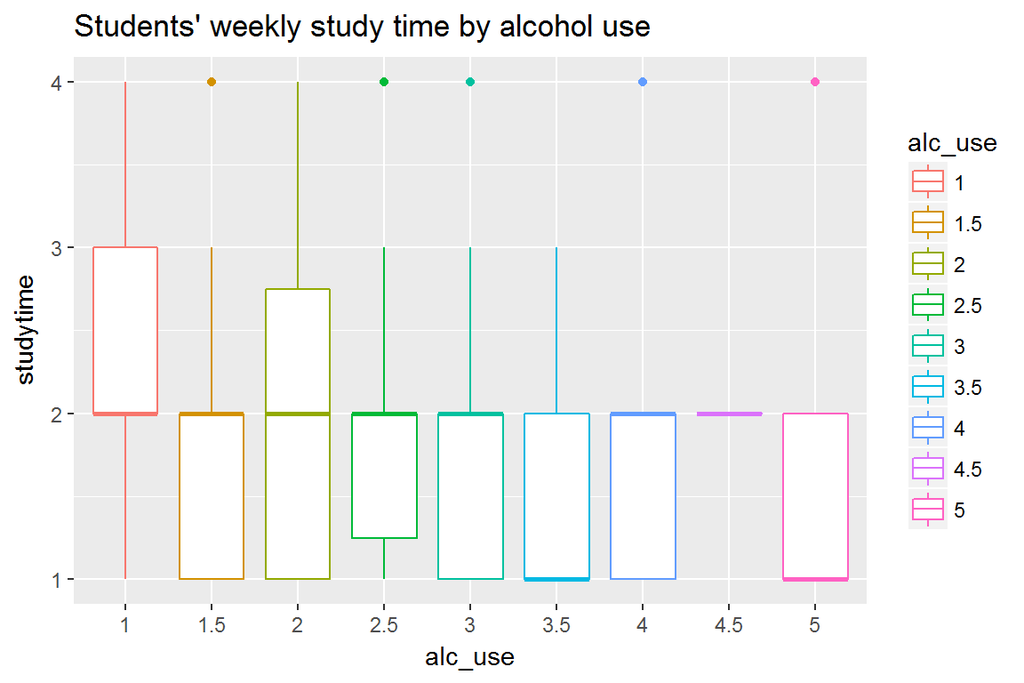

```r
library(ggplot2)

alc$alc_use<-as.factor(alc$alc_use)
# initialise a plot of high_use and absences
g2 <- ggplot(alc, aes(x = alc_use, y = studytime))

# define the plot as a boxplot and draw it
g2 + geom_boxplot() + ylab("studytime")+aes(col=alc_use)+ggtitle("Students' weekly study time by alcohol use")
```

*Figure 3. Box plots II*

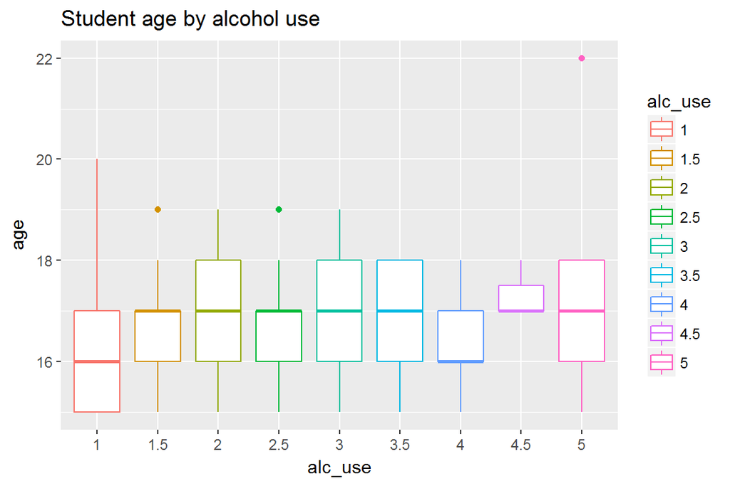

```r
library(ggplot2)

alc$alc_use<-as.factor(alc$alc_use)
# initialise a plot of high_use and absences
g2 <- ggplot(alc, aes(x = alc_use, y = age))

# define the plot as a boxplot and draw it
g2 + geom_boxplot() + ylab("age")+aes(col=alc_use)+ggtitle("Student age by alcohol use")
```

*Figure 4. Box plots III*

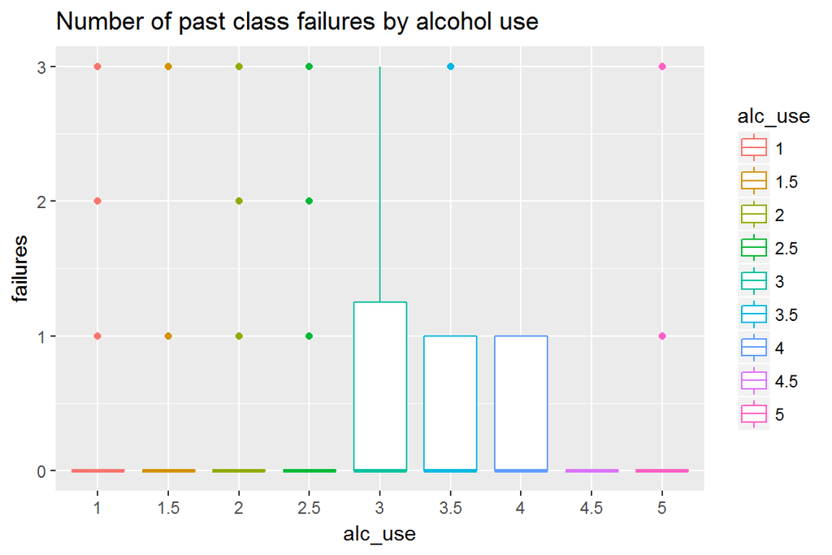

```r
library(ggplot2)

alc$alc_use<-as.factor(alc$alc_use)
# initialise a plot of high_use and absences
g2 <- ggplot(alc, aes(x = alc_use, y = failures))

# define the plot as a boxplot and draw it
g2 + geom_boxplot() + ylab("failures")+aes(col=alc_use)+ggtitle("Number of past class failures by alcohol use")
```

*Figure 5. Box plots IV*

**4.2. Comment on your findings and compare the results of your exploration to your previously stated hypotheses.**

*Distributions*

Figure 1 showed distributions of the variables:

Dependent variables

*Relationship*

However, cross-tabulations and box plots describe the relationship more deeply; showing that there are also a lot of variations.

Table 1 and also figure 1 showed that most students going out about average (2 or 3) have quite low alcohol use, while most of those students going out very high level have also high alcohol use.

**5. Use logistic regression to statistically explore the relationship between your chosen variables and the binary high/low alcohol consumption variable as the target variable. Present and interpret a summary of the fitted model. Present and interpret the coefficients of the model as odds ratios and provide confidence intervals for them. Interpret the results and compare them to your previously stated hypothesis.**

```r
# find the model with glm()
m <- glm(high_use ~ goout+ studytime+age+failures, data = dta, family = "binomial")

# print out a summary of the model
summary(m)
```

```
##
## Call:
## glm(formula = high_use ~ goout + studytime + age + failures,
##     family = "binomial", data = dta)
##
## Deviance Residuals:
##     Min       1Q   Median       3Q      Max
## -1.8036  -0.7813  -0.5332   0.8684   2.5526
##
## Coefficients:
##             Estimate Std. Error z value Pr(>|z|)
## (Intercept) -3.76790    1.84119  -2.046  0.04071 *
## goout        0.70987    0.11705   6.064 1.32e-09 ***
## studytime   -0.59020    0.16849  -3.503  0.00046 ***
## age          0.09935    0.11028   0.901  0.36764
## failures     0.17576    0.17195   1.022  0.30672
## ---
## Signif. codes:  0 '***' 0.001 '**' 0.01 '*' 0.05 '.' 0.1 ' ' 1
##
## (Dispersion parameter for binomial family taken to be 1)
##
##     Null deviance: 462.21  on 381  degrees of freedom
## Residual deviance: 394.64  on 377  degrees of freedom
## AIC: 404.64
##
## Number of Fisher Scoring iterations: 4
```

**Interpret a summary of the fitted model.**

Below, you found summary of the fitted model. As the z-value are only significant (enough big) for goout and studytime, the corresponding variables only matters (the corresponding true regression coefficient is not 0). In the other words, only relationships between goout and high_use, and studytime and high_use are significant.

Noted also that that the standard errors of these four study variables were quite low (below 1); indicating that they are not too spread out.

```r
# print out the coefficients of the model
coef(m)
```

```
## (Intercept)       goout   studytime         age    failures
## -3.76789872  0.70986928 -0.59020183  0.09935216  0.17575616
```

```r
# compute odds ratios (OR)
OR <- coef(m) %>% exp

# compute confidence intervals (CI)
CI<-exp(confint(m))
# print out the odds ratios with their confidence intervals
cbind(OR, CI)
```

```
##                     OR        2.5 %    97.5 %
## (Intercept) 0.02310055 0.0005942399 0.8239749
## goout       2.03372540 1.6262645163 2.5759180
## studytime   0.55421541 0.3939867475 0.7640697
## age         1.10445518 0.8902994937 1.3733059
## failures    1.19214732 0.8494144571 1.6720407
```

**Interpret the coefficients of the model as odds ratios**

We only interpret the significant variables:

The odds ratios OR=2.03 for going out with friends was higher than one; indicating positive relationship. More student go out with friends, the more his/her alcohol use is at a high level (TRUE). In other words, if students go out with friends often, he/she have about 2 times likely to have high alcohol use.

**compare them to your previously stated hypothesis.**

Only hypothesis H1 (Going out with friends might have a positive association with alcohol consumption) and H2 (Weekly study time might have a negative association with alcohol consumption) were evident when these four dependent variables were at the same logistic regression model (controlling the each other’s effects).

**6. Using the variables which, according to your logistic regression model, had a statistical relationship with high/low alcohol consumption, explore the predictive power of you model. Provide a 2x2 cross tabulation of predictions versus the actual values and optionally display a graphic visualizing both the actual values and the predictions. Compute the total proportion of inaccurately classified individuals (= the training error) and comment on all the results. Compare the performance of the model with performance achieved by some simple guessing strategy.**

Noted that only variables that have significant relationship with high/low alcohol consumptions were left in the next model.

```r
# fit the model
m <- glm(high_use ~ goout + studytime, data = dta, family = "binomial")

# predict() the probability of high_use
probabilities <- predict(m, type = "response")

# add the predicted probabilities to 'alc'
dta <- mutate(dta, probability = probabilities)

# use the probabilities to make a prediction of high_use
dta <- mutate(dta, prediction = probability>0.5)

# tabulate the target variable versus the predictions
table(high_use = dta$high_use, prediction = dta$prediction)
```

```
##         prediction
## high_use FALSE TRUE
##    FALSE   248   22
##    TRUE     70   42
```

```r
table(high_use = dta$high_use, prediction = dta$prediction) %>% prop.table() %>% addmargins()
```

```
##         prediction
## high_use      FALSE       TRUE        Sum
##    FALSE 0.64921466 0.05759162 0.70680628
##    TRUE  0.18324607 0.10994764 0.29319372
##    Sum   0.83246073 0.16753927 1.00000000
```

**7. Bonus: Perform 10-fold cross-validation on your model. Does your model have better test set performance (smaller prediction error using 10-fold cross-validation) compared to the model introduced in DataCamp (which had about 0.26 error). Could you find such a model?**

```r
# define a loss function (average prediction error)
loss_func <- function(class, prob) {
  n_wrong <- abs(class - prob) > 0.5
  mean(n_wrong)
}

# compute the average number of wrong predictions in the (training) data
loss_func(dta$high_use, dta$probability)
```

```
## [1] 0.2408377
```

```r
# K-fold cross-validation
library(boot)
cv <- cv.glm(data = dta, cost = loss_func, glmfit = m, K = 10)

# average number of wrong predictions in the cross validation
cv$delta[1]
```

```
## [1] 0.2408377
```

Above you found the 10-fold cross-validation syntax and error as output. The data is divided into subsets 10 times and eventually all the data is used for both training and testing.

My model has about 0.24 training and testing errors, and thus my model is better than the model introduced in DataCamp (which had about 0.26 error)

**8. Super-Bonus: Perform cross-validation to compare the performance of different logistic regression models (= different sets of predictors). Start with a very high number of predictors and explore the changes in the training and testing errors as you move to models with less predictors. Draw a graph displaying the trends of both training and testing errors by the number of predictors in the model.**

**MODEL1**

First model with very high number of predictors

```r
# fit the model
m <- glm(high_use ~ school+ age+ failures + absences + sex+internet+schoolsup+famsup+paid+activities+higher+romantic+Medu+Fedu+traveltime+studytime+famrel+freetime+goout+health+G1+G2+G3, data = alc, family = "binomial")

# print out a summary of the model
summary(m)
```

```
##
## Call:
## glm(formula = high_use ~ school + age + failures + absences +
##     sex + internet + schoolsup + famsup + paid + activities +
##     higher + romantic + Medu + Fedu + traveltime + studytime +
##     famrel + freetime + goout + health + G1 + G2 + G3, family = "binomial",
##     data = alc)
##
## Deviance Residuals:
##     Min       1Q   Median       3Q      Max
## -1.7676  -0.6984  -0.4146   0.5511   2.6452
##
## Coefficients:
##               Estimate Std. Error z value Pr(>|z|)
## (Intercept)   -4.47222    2.71628  -1.646 0.099671 .
## schoolMS       0.07936    0.49215   0.161 0.871888
## age            0.07185    0.13871   0.518 0.604479
## failures       0.16623    0.21566   0.771 0.440820
## absences       0.06836    0.01808   3.781 0.000156 ***
## sexM           0.94855    0.31300   3.031 0.002441 **
## internetyes   -0.13830    0.40076  -0.345 0.730020
## schoolsupyes  -0.18560    0.44390  -0.418 0.675869
## famsupyes     -0.20794    0.31073  -0.669 0.503368
## paidyes        0.62269    0.29995   2.076 0.037897 *
## activitiesyes -0.50000    0.28663  -1.744 0.081090 .
## higheryes     -0.22285    0.69263  -0.322 0.747653
## romanticyes   -0.32750    0.31513  -1.039 0.298687
## Medu          -0.16788    0.17488  -0.960 0.337051
## Fedu           0.21586    0.17454   1.237 0.216186
## traveltime     0.47690    0.21231   2.246 0.024689 *
## studytime     -0.27991    0.19194  -1.458 0.144757
## famrel        -0.48392    0.15708  -3.081 0.002065 **
## freetime       0.20776    0.15361   1.352 0.176228
## goout          0.78514    0.14134   5.555 2.78e-08 ***
## health         0.15662    0.10301   1.520 0.128420
## G1            -0.17182    0.09110  -1.886 0.059289 .
## G2             0.11897    0.11396   1.044 0.296508
## G3             0.03662    0.08252   0.444 0.657196
## ---
## Signif. codes:  0 '***' 0.001 '**' 0.01 '*' 0.05 '.' 0.1 ' ' 1
##
## (Dispersion parameter for binomial family taken to be 1)
##
##     Null deviance: 462.21  on 381  degrees of freedom
## Residual deviance: 340.34  on 358  degrees of freedom
## AIC: 388.34
##
## Number of Fisher Scoring iterations: 5
```

```r
# print out the coefficients of the model
coef(m)
```

```
##   (Intercept)      schoolMS           age      failures      absences
##   -4.47222082    0.07936423    0.07184607    0.16623121    0.06836059
##          sexM   internetyes  schoolsupyes     famsupyes       paidyes
##    0.94854610   -0.13830143   -0.18559565   -0.20793732    0.62268537
## activitiesyes     higheryes   romanticyes          Medu          Fedu
##   -0.50000158   -0.22284511   -0.32749905   -0.16788349    0.21586182
##    traveltime     studytime        famrel      freetime         goout
##    0.47690408   -0.27990842   -0.48391665    0.20775575    0.78514099
##        health            G1            G2            G3
##    0.15661541   -0.17181500    0.11897195    0.03662077
```

```r
# predict() the probability of high_use
probabilities <- predict(m, type = "response")

# add the predicted probabilities to 'alc'
alc <- mutate(alc, probability = probabilities)

# use the probabilities to make a prediction of high_use
alc <- mutate(alc, prediction = probability>0.5)

# tabulate the target variable versus the predictions
table(high_use = alc$high_use, prediction = alc$prediction)
```

```
##         prediction
## high_use FALSE TRUE
##    FALSE   253   17
##    TRUE     54   58
```

```r
# define a loss function (average prediction error)
loss_func <- function(class, prob) {
  n_wrong <- abs(class - prob) > 0.5
  mean(n_wrong)
}

# compute the average number of wrong predictions in the (training) data
loss_func(alc$high_use, alc$probability)
```

```
## [1] 0.1858639
```

```r
# K-fold cross-validation
library(boot)
cv <- cv.glm(data = alc, cost = loss_func, glmfit = m, K = 10)

# average number of wrong predictions in the cross validation
cv$delta[1]
```

```
## [1] 0.2356021
```

**MODEL2**

In this second model, only significant variables will be let in the model2: absences, sex, paid, activities, traveltime, famrel, goout, and G1.

```r
# fit the model
m <- glm(high_use ~ absences + sex+paid+activities+traveltime+famrel+goout+G1, data = alc, family = "binomial")

# print out a summary of the model
summary(m)
```

```
##
## Call:
## glm(formula = high_use ~ absences + sex + paid + activities +
##     traveltime + famrel + goout + G1, family = "binomial", data = alc)
##
## Deviance Residuals:
##     Min       1Q   Median       3Q      Max
## -2.0999  -0.7200  -0.4520   0.6456   2.9602
##
## Coefficients:
##               Estimate Std. Error z value Pr(>|z|)
## (Intercept)   -2.96357    0.89179  -3.323  0.00089 ***
## absences       0.06639    0.01678   3.956 7.63e-05 ***
## sexM           1.20658    0.27761   4.346 1.38e-05 ***
## paidyes        0.46782    0.26894   1.739  0.08195 .
## activitiesyes -0.57222    0.27011  -2.118  0.03414 *
## traveltime     0.45079    0.18804   2.397  0.01651 *
## famrel        -0.45235    0.14481  -3.124  0.00179 **
## goout          0.80909    0.13091   6.180 6.39e-10 ***
## G1            -0.04001    0.04087  -0.979  0.32757
## ---
## Signif. codes:  0 '***' 0.001 '**' 0.01 '*' 0.05 '.' 0.1 ' ' 1
##
## (Dispersion parameter for binomial family taken to be 1)
##
##     Null deviance: 462.21  on 381  degrees of freedom
## Residual deviance: 356.39  on 373  degrees of freedom
## AIC: 374.39
##
## Number of Fisher Scoring iterations: 5
```

```r
# print out the coefficients of the model
coef(m)
```

```
##   (Intercept)      absences          sexM       paidyes activitiesyes
##   -2.96356793    0.06638932    1.20658118    0.46781964   -0.57222077
##    traveltime        famrel         goout            G1
##    0.45079294   -0.45234746    0.80908756   -0.04001193
```

```r
# predict() the probability of high_use
probabilities <- predict(m, type = "response")

# add the predicted probabilities to 'alc'
alc <- mutate(alc, probability = probabilities)

# use the probabilities to make a prediction of high_use
alc <- mutate(alc, prediction = probability>0.5)

# tabulate the target variable versus the predictions
table(high_use = alc$high_use, prediction = alc$prediction)
```

```
##         prediction
## high_use FALSE TRUE
##    FALSE   256   14
##    TRUE     58   54
```

```r
# define a loss function (average prediction error)
loss_func <- function(class, prob) {
  n_wrong <- abs(class - prob) > 0.5
  mean(n_wrong)
}

# compute the average number of wrong predictions in the (training) data
loss_func(alc$high_use, alc$probability)
```

```
## [1] 0.1884817
```

```r
# K-fold cross-validation
library(boot)
cv <- cv.glm(data = alc, cost = loss_func, glmfit = m, K = 10)

# average number of wrong predictions in the cross validation
cv$delta[1]
```

```
## [1] 0.2120419
```

As the testing error in the MODEL2 is lower than in the MODEL1, we are moving forward.

**MODEL3**

Only significant will be let in the third model: absences, sex, paid, activities, traveltime, famrel, and goout.

```r
# fit the model
m <- glm(high_use ~ absences + sex+paid+activities+traveltime+famrel+goout, data = alc, family = "binomial")

# print out a summary of the model
summary(m)
```

```
##
## Call:
## glm(formula = high_use ~ absences + sex + paid + activities +
##     traveltime + famrel + goout, family = "binomial", data = alc)
##
## Deviance Residuals:
##     Min       1Q   Median       3Q      Max
## -2.0675  -0.7223  -0.4531   0.6708   2.8999
##
## Coefficients:
##               Estimate Std. Error z value Pr(>|z|)
## (Intercept)   -3.45743    0.74523  -4.639 3.49e-06 ***
## absences       0.06708    0.01674   4.007 6.16e-05 ***
## sexM           1.18030    0.27583   4.279 1.88e-05 ***
## paidyes        0.44611    0.26714   1.670  0.09494 .
## activitiesyes -0.59722    0.26886  -2.221  0.02633 *
## traveltime     0.47011    0.18649   2.521  0.01171 *
## famrel        -0.45315    0.14489  -3.128  0.00176 **
## goout          0.83028    0.12985   6.394 1.61e-10 ***
## ---
## Signif. codes:  0 '***' 0.001 '**' 0.01 '*' 0.05 '.' 0.1 ' ' 1
##
## (Dispersion parameter for binomial family taken to be 1)
##
##     Null deviance: 462.21  on 381  degrees of freedom
## Residual deviance: 357.35  on 374  degrees of freedom
## AIC: 373.35
##
## Number of Fisher Scoring iterations: 5
```

```r
# print out the coefficients of the model
coef(m)
```

```
##   (Intercept)      absences          sexM       paidyes activitiesyes
##   -3.45743452    0.06707767    1.18030243    0.44610789   -0.59722408
##    traveltime        famrel         goout
##    0.47011168   -0.45314583    0.83027754
```

```r
# predict() the probability of high_use
probabilities <- predict(m, type = "response")

# add the predicted probabilities to 'alc'
alc <- mutate(alc, probability = probabilities)

# use the probabilities to make a prediction of high_use
alc <- mutate(alc, prediction = probability>0.5)

# tabulate the target variable versus the predictions
table(high_use = alc$high_use, prediction = alc$prediction)
```

```
##         prediction
## high_use FALSE TRUE
##    FALSE   255   15
##    TRUE     56   56
```

```r
# define a loss function (average prediction error)
loss_func <- function(class, prob) {
  n_wrong <- abs(class - prob) > 0.5
  mean(n_wrong)
}

# compute the average number of wrong predictions in the (training) data
loss_func(alc$high_use, alc$probability)
```

```
## [1] 0.1858639
```

```r
# K-fold cross-validation
library(boot)
cv <- cv.glm(data = alc, cost = loss_func, glmfit = m, K = 10)

# average number of wrong predictions in the cross validation
cv$delta[1]
```

```
## [1] 0.1963351
```

As the training and testing error in the MODEL3 are slightly lower than in the MODEL2, this MODEL3 might be better.